# Discipline Assessment 2 - Stock

Author

520397297

## Import Data

```r
library(readr)

stock1 <- read_csv("stock_1.csv")
str(stock1)
head(stock1)
```

```r
summary(stock1)
```

```
    time_id      seconds_in_bucket   bid_price1       ask_price1
 Min.   :    5   Min.   :  0.0     Min.   :0.9375   Min.   :0.9382
 1st Qu.: 7883   1st Qu.:147.0     1st Qu.:0.9980   1st Qu.:0.9986
 Median :15861   Median :296.0     Median :0.9997   Median :1.0003
 Mean   :16078   Mean   :297.3     Mean   :0.9996   Mean   :1.0003
 3rd Qu.:24022   3rd Qu.:447.0     3rd Qu.:1.0013   3rd Qu.:1.0019
 Max.   :32767   Max.   :599.0     Max.   :1.0493   Max.   :1.0636
   bid_price2       ask_price2       bid_size1       ask_size1
 Min.   :0.9369   Min.   :0.9384   Min.   :    1   Min.   :    1.0
 1st Qu.:0.9979   1st Qu.:0.9988   1st Qu.:   59   1st Qu.:   77.0
 Median :0.9996   Median :1.0004   Median :  101   Median :  101.0
 Mean   :0.9995   Mean   :1.0005   Mean   :  140   Mean   :  142.7
 3rd Qu.:1.0011   3rd Qu.:1.0021   3rd Qu.:  200   3rd Qu.:  200.0
 Max.   :1.0491   Max.   :1.0646   Max.   :20896   Max.   :21002.0
   bid_size2         ask_size2          stock_id
 Min.   :    1.0   Min.   :    1.0   Min.   :1
 1st Qu.:   58.0   1st Qu.:   65.0   1st Qu.:1
 Median :  100.0   Median :  100.0   Median :1
 Mean   :  131.3   Mean   :  134.8   Mean   :1
 3rd Qu.:  200.0   3rd Qu.:  200.0   3rd Qu.:1
 Max.   :20896.0   Max.   :35329.0   Max.   :1
```

## Compute Statistics

```r
# compute wap and bidaskspread
stock1 <- stock1 %>%
  mutate(
    WAP = (bid_price1 * ask_size1 + ask_price1 * bid_size1) / (bid_size1 + ask_size1),
    BidAskSpread = ask_price1 / bid_price1 - 1
  )

# compute log returns per timeid (with 0s for unchanged waps)
log_r1 <- list()
time_IDs <- unique(stock1$time_id)[1:500]  # first 500 time_ids

for (i in seq_along(time_IDs)) {
  sec <- stock1 %>% filter(time_id == time_IDs[i]) %>% pull(seconds_in_bucket)
  price <- stock1 %>% filter(time_id == time_IDs[i]) %>% pull(WAP)

  log_r <- log(price[-1] / price[-length(price)])
  log_r1[[i]] <- data.frame(time = sec[-1], log_return = log_r)

  # identify timestamps with no change or missing values
  time.no.change <- setdiff(1:600, log_r1[[i]]$time)
  if (length(time.no.change) > 0) {
    zero_df <- data.frame(time = time.no.change, log_return = 0)
    log_r1[[i]] <- rbind(log_r1[[i]], zero_df)
    log_r1[[i]] <- log_r1[[i]][order(log_r1[[i]]$time), ]
  }
}

# compute realized volatility
bucket_size <- 20
comp_vol <- function(x) sqrt(sum(x^2))
vol <- list()

for (i in seq_along(log_r1)) {
  log_r1[[i]] <- log_r1[[i]] %>%
    mutate(time_bucket = ceiling(time / bucket_size))

  vol[[i]] <- aggregate(log_return ~ time_bucket, log_r1[[i]], FUN = comp_vol)
  colnames(vol[[i]]) <- c("time_bucket", "volatility")
}
```

### Visualization

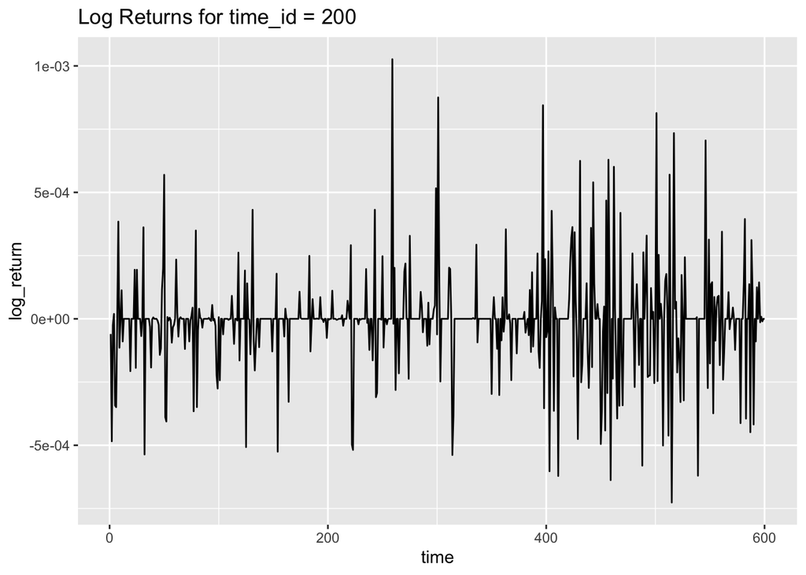

```r
# log returns for time_id = 200
ggplot(data = log_r1[[200]], aes(x = time, y = log_return)) +
  geom_line() +
  labs(title = "Log Returns for time_id = 200")
```

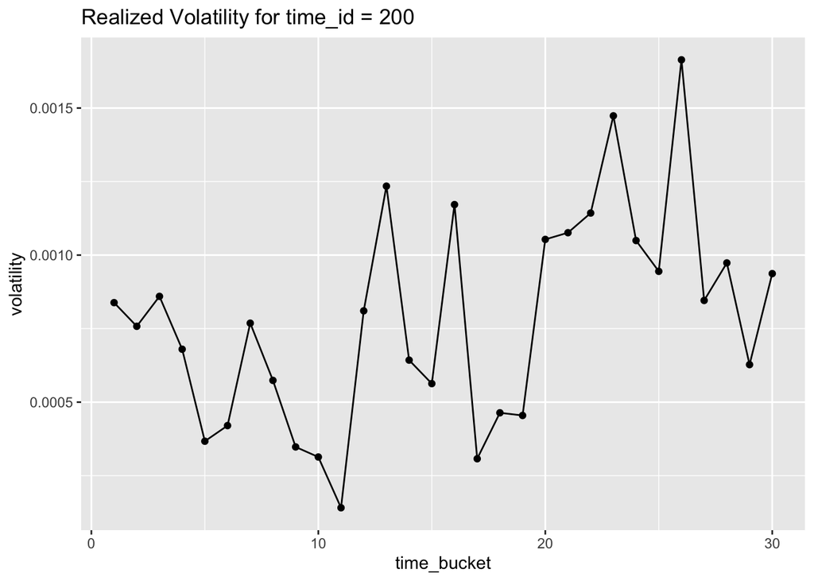

```r
# realized volatility
ggplot(data = vol[[200]], aes(x = time_bucket, y = volatility)) +
  geom_line() + geom_point() +
  labs(title = "Realized Volatility for time_id = 200")
```

### **1. Log Returns Plot**

- This plot shows the log returns **per second** over the full 600-second (10-minute) window for one trading session (time_id 200).
  - High-frequency dips and spikes: These show price volatility over short time periods.
  - Low fluctuation periods: When log returns are near zero, it indicates that the weighted average price, or WAP, hasn’t changed significantly.
  - Log return = 0 spikes: These result from your decision to incorporate 0-return points in cases when WAP remained unchanged, which is a wise move to maintain temporal continuity.

The price movement’s microstructure. Particularly when calculating realized volatility, relatively tiny variations can have an impact.

### **2. Realized Volatility Plot**

- This plot shows the actual volatility for the same session broken down into 20-second buckets.
- A popular stand-in for market activity, volatility is computed as the square root of the sum of squared log returns inside each bucket.
  - While later eras (buckets 20–30) exhibit significantly increased volatility, other periods (such as buckets 1–10) exhibit moderate to low volatility.
  - There is a clear growing trend, which might mean that later in the period there will be more trading activity or price instability.

This illustrates the volatility’s time trend. Aids in modeling (for example, forecasting future bucket volatility based on historical data), recognizing spikes in market activity, and influencing the temporal weighting of your model (more recent buckets can be more important).

## Estimation and prediction

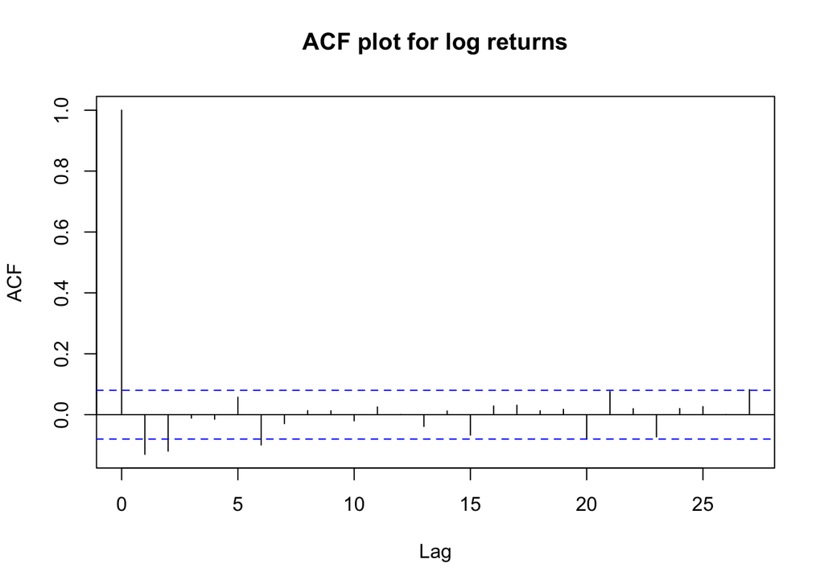

```r
# ACF plot for log returns and realised volatility of time_id = 200
acf(log_r1[[200]]$log_return, main = "ACF plot for log returns")
```

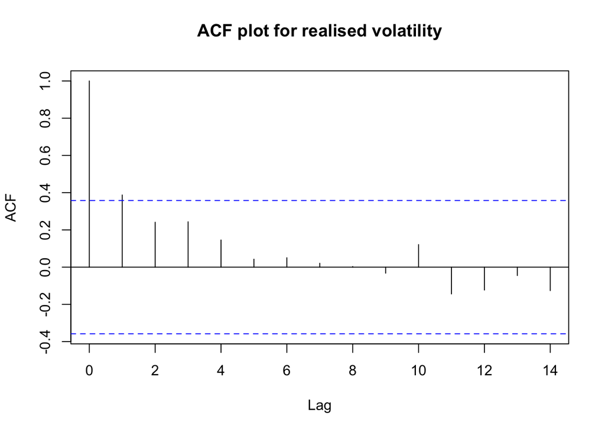

```r
acf(vol[[200]]$volatility, main = "ACF plot for realised volatility")
```

## Split into Training/Validation

```r
vol.train <- list()
vol.val <- list()

for (i in 1 : length(log_r1)) {
  vol.train[[i]] <- vol[[i]][1:24, ] # first 80%
  vol.val[[i]] <- vol[[i]][-(1:24), ] # remaining 20%
}
```

### Linear Regression (WLS)

```r
list.reg <- list()
stock1 <- stock1 %>% mutate(time_bucket = ceiling(seconds_in_bucket / 20),
                            num_order = bid_size1 + ask_size1 + bid_size2 + ask_size2)
len.train <- length(vol.train[[1]]$volatility)

for (i in 1 : length(vol)) {
  stats.bucket <- stock1 %>%
    filter(time_id == time_IDs[i] & time_bucket != 0) %>%
    select(c(BidAskSpread, WAP, num_order, time_bucket))
  # for each 20-sec time bucket, compute the following statistics
  mean.price <- aggregate(WAP ~ time_bucket, data = stats.bucket, FUN = mean)
  mean.order <- aggregate(num_order ~ time_bucket, data = stats.bucket, FUN = mean)
  mean.BAS <- aggregate(BidAskSpread ~ time_bucket, data = stats.bucket, FUN = mean)
  list.reg[[i]] <- data.frame(volatility = vol.train[[i]]$volatility[-1],
                              price = mean.price$WAP[1:(len.train - 1)],
                              order = mean.order$num_order[1:(len.train - 1)],
                              BidAskSpread = mean.BAS$BidAskSpread[1:(len.train - 1)])
}
```

```r
lm.models <- list()

for (i in 1 : length(vol)) {
  lm.models[[i]] <- lm(volatility ~ price + order + BidAskSpread, list.reg[[i]],
                       weights = 0.8 ^ (((len.train - 2):0) / 2))
}

# periods 162
summary(lm.models[[162]])
```

```
Call:
lm(formula = volatility ~ price + order + BidAskSpread, data = list.reg[[i]],
    weights = 0.8^(((len.train - 2):0)/2))

Weighted Residuals:
       Min         1Q     Median         3Q        Max
-1.919e-04 -4.944e-05 -1.819e-05  3.883e-05  2.546e-04

Coefficients:
               Estimate Std. Error t value Pr(>|t|)
(Intercept)  -2.412e-01  9.936e-02  -2.427   0.0253 *
price         2.418e-01  9.915e-02   2.439   0.0247 *
order        -5.923e-07  4.392e-07  -1.348   0.1934
BidAskSpread -4.097e-01  3.345e-01  -1.225   0.2355
---
Signif. codes:  0 '***' 0.001 '**' 0.01 '*' 0.05 '.' 0.1 ' ' 1

Residual standard error: 0.0001285 on 19 degrees of freedom
Multiple R-squared:  0.5656,    Adjusted R-squared:  0.497
F-statistic: 8.247 on 3 and 19 DF,  p-value: 0.001021
```

This regression model adds weight depending on the recentness of the data points rather than treating the entire set of data as a time series.

```r
global_reg_data <- data.frame()

for (i in 1:length(vol.train)) {
  len.train <- nrow(vol.train[[i]])

  stats.bucket <- stock1 %>%
    filter(time_id == time_IDs[i], time_bucket != 0) %>%
    select(time_id, BidAskSpread, WAP, num_order, time_bucket)

  mean.price <- aggregate(WAP ~ time_bucket, data = stats.bucket, mean)
  mean.order <- aggregate(num_order ~ time_bucket, data = stats.bucket, mean)
  mean.BAS <- aggregate(BidAskSpread ~ time_bucket, data = stats.bucket, mean)

  # assemble the data for this time_id
  temp_df <- data.frame(
    time_id = time_IDs[i],
    volatility = vol.train[[i]]$volatility[-1],
    price = mean.price$WAP[1:(len.train - 1)],
    order = mean.order$num_order[1:(len.train - 1)],
    BidAskSpread = mean.BAS$BidAskSpread[1:(len.train - 1)]
  )

  global_reg_data <- rbind(global_reg_data, temp_df)
}

global_model <- lm(volatility ~ price + order + BidAskSpread, data = global_reg_data)
summary(global_model)
```

```
Call:
lm(formula = volatility ~ price + order + BidAskSpread, data = global_reg_data)

Residuals:
       Min         1Q     Median         3Q        Max
-0.0047460 -0.0002720 -0.0000444  0.0002217  0.0107911

Coefficients:
               Estimate Std. Error t value Pr(>|t|)
(Intercept)   1.124e-02  1.166e-03   9.639   <2e-16 ***
price        -1.090e-02  1.166e-03  -9.349   <2e-16 ***
order        -2.011e-07  1.647e-08 -12.209   <2e-16 ***
BidAskSpread  7.772e-01  7.935e-03  97.951   <2e-16 ***
---
Signif. codes:  0 '***' 0.001 '**' 0.01 '*' 0.05 '.' 0.1 ' ' 1

Residual standard error: 0.0005449 on 11496 degrees of freedom
Multiple R-squared:  0.4687,    Adjusted R-squared:  0.4686
F-statistic:  3381 on 3 and 11496 DF,  p-value: < 2.2e-16
```

This global regression model identifies a general relationship between volatility and variables like price, order size, and bid-ask spread by merging data from various time_ids to build a single linear model over all time periods.

### HAV-RV Model

The HAV-RV model directly predicts the time series of realized volatility.

```r
list.HAV <- list()

for (i in 1 : length(vol)) {
  mean.vol <- rep(0, len.train - 5)
  for (j in 1 : 5) {
    mean.vol <- mean.vol + vol.train[[i]]$volatility[j : (j + len.train - 6)] / 5
  }
  list.HAV[[i]] <- data.frame(vol = vol.train[[i]]$volatility[-(1:5)],
                              vol_1 = vol.train[[i]]$volatility[5:(len.train - 1)],
                              mean_vol_5 = mean.vol)
}

# quarticity
comp_quar <- function(x) length(x) / 3 * sum(x^4)
quar <- lapply(log_r1, function(df) {
  q <- aggregate(log_return ~ time_bucket, df, comp_quar)
  colnames(q) <- c("time_bucket", "quarticity")
  q
})

HAV.ols.models <- list()
HAV.wls.models <- list()

for (i in seq_along(vol)) {
  HAV.ols.models[[i]] <- lm(vol ~ vol_1 + mean_vol_5, list.HAV[[i]])
  HAV.wls.models[[i]] <- lm(vol ~ vol_1 + mean_vol_5, list.HAV[[i]],
                            weights = list.HAV[[i]]$vol_1 /
                              sqrt(quar[[i]]$quarticity[5:(len.train - 1)]))
}
```

```r
summary(HAV.ols.models[[162]])  # OLS
```

```
Call:
lm(formula = vol ~ vol_1 + mean_vol_5, data = list.HAV[[i]])

Residuals:
       Min         1Q     Median         3Q        Max
-4.133e-04 -2.167e-04 -4.076e-05  1.111e-04  5.869e-04

Coefficients:
              Estimate Std. Error t value Pr(>|t|)
(Intercept)  4.035e-05  2.704e-04   0.149    0.883
vol_1       -1.255e-01  3.355e-01  -0.374    0.713
mean_vol_5   9.326e-01  6.797e-01   1.372    0.189

Residual standard error: 0.0003185 on 16 degrees of freedom
Multiple R-squared:  0.1372,    Adjusted R-squared:  0.02933
F-statistic: 1.272 on 2 and 16 DF,  p-value: 0.3072
```

```r
summary(HAV.wls.models[[162]])  # WLS
```

```
Call:
lm(formula = vol ~ vol_1 + mean_vol_5, data = list.HAV[[i]],
    weights = list.HAV[[i]]$vol_1/sqrt(quar[[i]]$quarticity[5:(len.train -
        1)]))

Weighted Residuals:
      Min        1Q    Median        3Q       Max
-0.016558 -0.007610 -0.001587  0.001881  0.026176

Coefficients:
              Estimate Std. Error t value Pr(>|t|)
(Intercept) -0.0001513  0.0001513  -1.000   0.3320
vol_1       -0.1908767  0.3452798  -0.553   0.5880
mean_vol_5   1.4407598  0.4999279   2.882   0.0108 *
---
Signif. codes:  0 '***' 0.001 '**' 0.01 '*' 0.05 '.' 0.1 ' ' 1

Residual standard error: 0.01339 on 16 degrees of freedom
Multiple R-squared:  0.4669,    Adjusted R-squared:  0.4002
F-statistic: 7.005 on 2 and 16 DF,  p-value: 0.006528
```

### XGBoost

Extreme Gradient Boosting (XGBoost), is a robust tree-based ensemble model that automatically selects features, manages outliers and skewed data well, and captures non-linear correlations. It works well with big structured datasets and is fast and scalable. XGBoost does not depend on rigid assumptions like normality or stationarity, in contrast to models like ARMA-GARCH or linear regression.

```r
# compute log returns before using it
stock1 <- stock1 %>%
  group_by(time_id) %>%
  arrange(seconds_in_bucket, .by_group = TRUE) %>%
  mutate(log_return = log(WAP / lag(WAP))) %>%
  ungroup()

features <- stock1 %>%
  group_by(time_id) %>%
  summarise(
    WAP_mean = mean(WAP),
    WAP_sd = sd(WAP),
    BidAskSpread_mean = mean(BidAskSpread),
    BidAskSpread_sd = sd(BidAskSpread),
    log_return_sd = sd(log_return, na.rm = TRUE)
  )

# computes realized volatility per time_id using squared log returns — a standard proxy for volatility
target <- stock1 %>%
  group_by(time_id) %>%
  summarise(realized_volatility = sqrt(sum(log_return^2, na.rm = TRUE)))

# combines features and target into a single dataset for supervised learning
final_df <- left_join(features, target, by = "time_id")

# 80/20 training vs testing
split_idx <- createDataPartition(final_df$realized_volatility, p = 0.8, list = FALSE)
train <- final_df[split_idx, ]
test <- final_df[-split_idx, ]

# removes the id and target variable from input features, resulting a clean numeric matrix
X_train <- as.matrix(select(train, -time_id, -realized_volatility))
y_train <- train$realized_volatility
X_test <- as.matrix(select(test, -time_id, -realized_volatility))
y_test <- test$realized_volatility

# trains a regression model (predicting volatility, a continuous value) using 100 boosting rounds
xgb_model <- xgboost(
  data = X_train,
  label = y_train,
  nrounds = 100,
  objective = "reg:squarederror",
  verbose = 0
)
```

```r
# ranks how important each feature is in splitting the trees — helpful for explaining what drives volatility in the model
xgb.importance(model = xgb_model)
```

```
             Feature        Gain      Cover Frequency
              <char>       <num>      <num>     <num>
1:     log_return_sd 0.908689968 0.49072647 0.3323782
2:            WAP_sd 0.056655740 0.14489241 0.1633238
3:   BidAskSpread_sd 0.016138373 0.14251735 0.2177650
4: BidAskSpread_mean 0.010944792 0.13676630 0.1461318
5:          WAP_mean 0.007571127 0.08509748 0.1404011
```

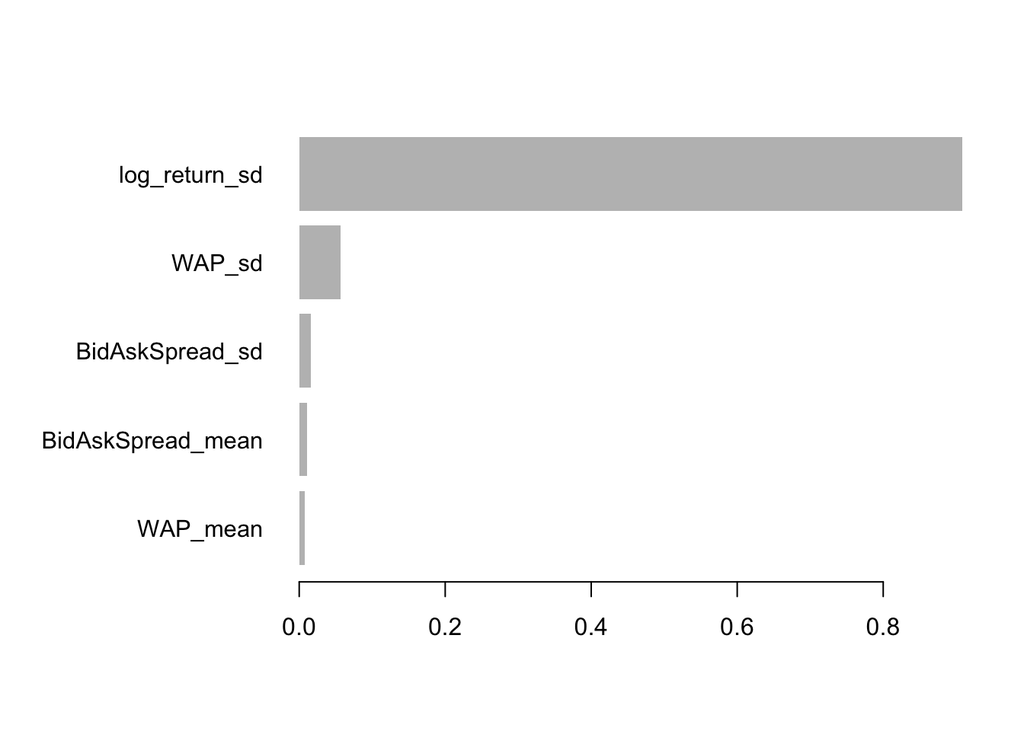

```r
xgb.plot.importance(xgb.importance(model = xgb_model))
```

## Assessing the model (Prediction)

### Linear & HAV-RV Validation Predictions

```r
pred.lm <- list()
pred.hav <- list()
list.reg.val <- list()

for (i in seq_along(vol)) {
  len.val <- length(vol.val[[i]]$volatility)

  stats.bucket <- stock1 %>%
    filter(time_id == time_IDs[i] & time_bucket != 0) %>%
    select(BidAskSpread, WAP, num_order, time_bucket)

  mean.price <- aggregate(WAP ~ time_bucket, stats.bucket, mean)
  mean.order <- aggregate(num_order ~ time_bucket, stats.bucket, mean)
  mean.BAS <- aggregate(BidAskSpread ~ time_bucket, stats.bucket, mean)

  # feature matrix
  list.reg.val[[i]] <- data.frame(
    volatility = vol.val[[i]]$volatility,
    price = mean.price$WAP[len.train:(len.train + len.val - 1)],
    order = mean.order$num_order[len.train:(len.train + len.val - 1)],
    BidAskSpread = mean.BAS$BidAskSpread[len.train:(len.train + len.val - 1)]
  )

  # predictions
  pred.lm[[i]] <- predict(lm.models[[i]], newdata = list.reg.val[[i]])
  pred.hav[[i]] <- predict(HAV.wls.models[[i]], newdata = list.HAV[[i]])
}
```

### XGBoost Predictions

```r
pred_xgb <- predict(xgb_model, X_test)
```

## Evaluate All Models

```r
library(Metrics)

qlike <- function(actual, predicted) {
  mean((actual / predicted) - log(actual / predicted) - 1, na.rm = TRUE)
}

evaluate_model <- function(true, pred) {
  data.frame(
    MAE = mae(true, pred),
    RMSE = rmse(true, pred),
    R2 = R2(pred, true),
    QLIKE = qlike(true, pred)
  )
}
```

```r
y_true <- sapply(vol.val[1:100], function(df) df$volatility[1])
```

```r
# first prediction from each model's validation predictions
y_reg   <- sapply(pred.lm[1:100], function(x) x[1])
y_hav   <- sapply(pred.hav[1:100], function(x) x[1])
y_xgb   <- pred_xgb[1:100]
```

```r
evaluate_model_xgb <- function(true, pred) {
  true <- as.numeric(true)
  pred <- as.numeric(pred)
  data.frame(
    MAE = mae(true, pred),
    RMSE = rmse(true, pred),
    R2 = caret::R2(pred, true),
    QLIKE = qlike(true, pred)
  )
}


results_comp <- rbind(
  Linear  = evaluate_model(y_true, y_reg),
  HAV_RV  = evaluate_model(y_true, y_hav),
  XGBoost = evaluate_model_xgb(y_test, pred_xgb)
)

round(results_comp, 6)
```

```
             MAE     RMSE       R2    QLIKE
Linear  0.000315 0.000435 0.622229 0.168665
HAV_RV  0.000312 0.000444 0.601385 0.191400
XGBoost 0.000463 0.000728 0.953548 0.008318
```

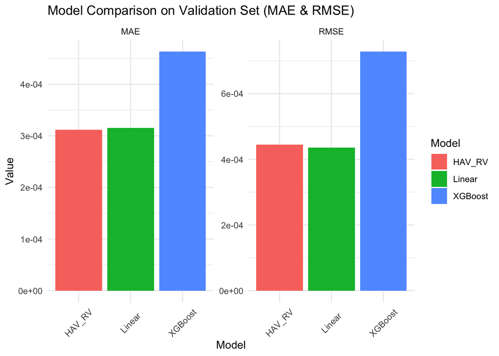

```r
results_comp$Model <- rownames(results_comp)
results_melt <- melt(results_comp, id.vars = "Model")
colnames(results_melt) <- c("Model", "Metric", "Value")

results_melt_subset <- results_melt %>%
  filter(Metric %in% c("MAE", "RMSE"))

ggplot(results_melt_subset, aes(x = Model, y = Value, fill = Model)) +
  geom_bar(stat = "identity", position = "dodge") +
  facet_wrap(~ Metric, scales = "free_y") +
  theme_minimal() +
  labs(
    title = "Model Comparison on Validation Set (MAE & RMSE)",
    x = "Model",
    y = "Value"
  ) +
  theme(axis.text.x = element_text(angle = 45, vjust = 0.5))
```

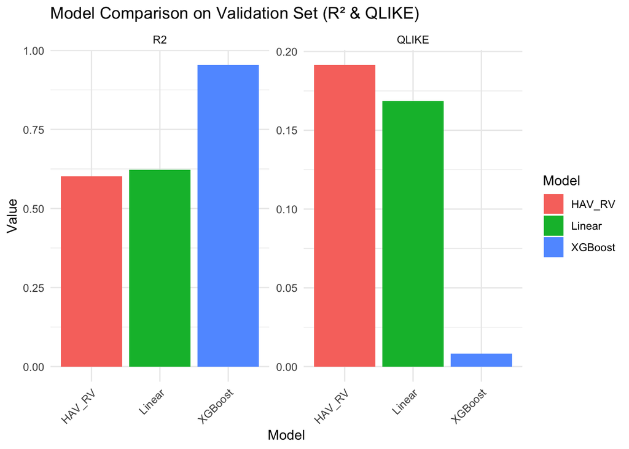

```r
results_comp$Model <- rownames(results_comp)
results_melt <- melt(results_comp, id.vars = "Model")
colnames(results_melt) <- c("Model", "Metric", "Value")

results_melt_subset <- results_melt %>%
  filter(Metric %in% c("R2", "QLIKE"))

ggplot(results_melt_subset, aes(x = Model, y = Value, fill = Model)) +
  geom_bar(stat = "identity", position = "dodge") +
  facet_wrap(~ Metric, scales = "free_y") +
  theme_minimal() +
  labs(
    title = "Model Comparison on Validation Set (R² & QLIKE)",
    x = "Model",
    y = "Value"
  ) +
  theme(axis.text.x = element_text(angle = 45, hjust = 1))
```